# Assignment 1

```r
setwd('/Users/leonarddariusvorbeck/Desktop/_EDDA_')
```

### Exc. 1 - Birthweights

The data set birthweight.txt contains the birthweights of 188 newborn babies. We are interested in finding the underlying (population) mean µ of birthweights.

```r
births=read.table("birthweight.txt",header=TRUE)$birthweight
summary(births)
```

```
   Min. 1st Qu.  Median    Mean 3rd Qu.    Max.
    955    2479    2902    2913    3468    4922
```

a.1) Check normality of the data.

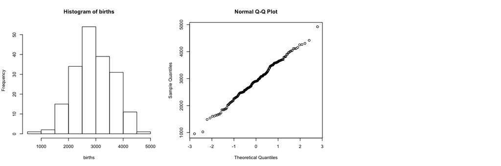

```r
par(mfrow=c(1,3));options(repr.plot.width=12, repr.plot.height=4)
hist(births)
qqnorm(births)
```

It is reasonable to assume the data is sampled from a somewhat normal distribution. The QQ plot reveals that the quantiles of the sample are aligning with the theoretical quantiles of $\mathcal{N}(0, 1)$. The histogram additionally supports that.

a.2) Compute a point estimate for µ. Derive, assuming normality (irrespective of your conclusion about normality od the data), a bounded 90% confidence interval for µ.

As a point estimate for $\mu$, the sample mean $\bar{X} = \frac{1}{n} \sum_i X_i$ is used.

```r
alpha = 0.1
n = length(births)
mu_estimate = mean(births)
sigma_estimate = sd(births)
```

```r
mu_estimate
```

2913.29255319149

Since $\sigma$ is unknown, we have to use $s$ to create a confidence interval for our estimate and therefore the t-test. The CI is obtained via

$$ \bar{X} \pm t_{\alpha / 2} \frac{s}{\sqrt{n}}=\left[\bar{X}-t_{\alpha / 2} \frac{s}{\sqrt{n}}, \bar{X}+t_{\alpha / 2} \frac{s}{\sqrt{n}}\right] $$

```r
t_alpha = qt(1-(alpha/2),df=n-1)
CI = c(mu_estimate - (t_alpha) * (sigma_estimate / sqrt(n)),
       mu_estimate + (t_alpha) * (sigma_estimate / sqrt(n)))
CI
```

1. 2829.20154724168

2. 2997.3835591413

$\bar{X} = 2913$ is concluded to be an appropiate estimate for the population mean since $\bar{X} \in [ 2830 , 3000]$ (90 % CI). Alternatively, we chan check that via the t-test :

```r
t.test(births,mu=2913, conf.level = 0.9)
```

```
	One Sample t-test

data:  births
t = 0.0057509, df = 187, p-value = 0.9954
alternative hypothesis: true mean is not equal to 2913
90 percent confidence interval:
 2829.202 2997.384
sample estimates:
mean of x
 2913.293
```

b.) An expert claims that the mean birthweight is bigger than 2800, verify this claim by using a t-test. What is the outcome of the test if you take α = 0.1? And other values of α?

$H_0 \gets \mu \leq 2800 \implies H_1 : \mu > 2800 $

```r
alpha = 0.1
t.test(births,mu=2800, conf.level = 1-alpha, alternative="greater")
```

```
	One Sample t-test

data:  births
t = 2.2271, df = 187, p-value = 0.01357
alternative hypothesis: true mean is greater than 2800
90 percent confidence interval:
 2847.868      Inf
sample estimates:
mean of x
 2913.293
```

$H_0$ is rejected, $p < 0.05$. If we vary $\alpha$, the CIs will change according to the previously used formula for the CI. While the upper bound wont change, the lower bound of the CI will.

```r
alphas = seq(0.01, 0.99, length.out=100)
lower_bounds = sapply(alphas,
           function(alpha){return(t.test(births,
                                         mu=2800,
                                         conf.level = 1-alpha,
                                         alternative="greater")$conf.int[1])} )
```

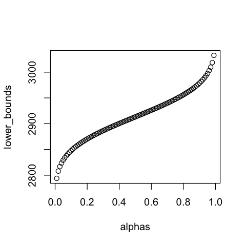

```r
options(repr.plot.width=4, repr.plot.height=4);
plot(alphas, lower_bounds)
```

c.) In the R-output of the test from b), also a confidence interval is given, but why is it different from the confidence interval found in a) and why is it one-sided?

This is expected if the hypothesis is one-tailed ( >, <), the CI is also one-sided, effectively yielding an upper or lower bound , i.e $\left(-\infty, \bar{X}+t_{\alpha, n-1} \frac{S}{\sqrt{n}}\right)$ or $\left(\bar{X}-t_{\alpha, n-1} \frac{S}{\sqrt{n}},+\infty\right)$.

## Exc. 2 - Power function of the t-test

We study the power function of the two-sample t-test. \ For n=m=30, mu=180, nu=175 and sd=5, generate 1000 samples x=rnorm(n,mu,sd) and y=rnorm(m,nu,sd), and record the 1000 p-values for testing H0: mu=nu. \ You can evaluate the power (at point nu=175) of this t-test as fraction of p-values that are smaller than 0.05.

Note that $H_0 : \mu = \nu \implies H_0 : \mu - \nu = 0 $, which seems to be the calculation baseline for the t object implemented in R. The power of the test is $$ \textbf{power} = P(\textit{Reject} \ H_0| \neg H_0 ) $$

```r
#sample size
n=m=30
#total samples
N = 1000
#density props
x_mean = 180
y_mean= 175
std = 5
```

```r
p_vals = numeric(N)
for(i in 1:N){p_vals[i]=t.test(x=rnorm(m, x_mean, std),
                                      y=rnorm(n, y_mean, std))$p.value}
```

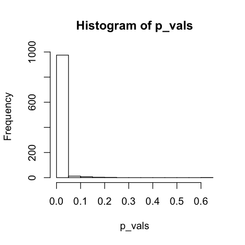

```r
# Estimated density of MC-pseudo p-values
hist(p_vals)
```

```r
power = length(p_vals[p_vals<0.05])/length(p_vals)
power
```

0.975

Given power $P\in [0,1]$, $P=0.97$ looks good. It represents the power of the test at $\nu = 175$ i.e.

$$ P(\textit{Reject} \ H_0| \neg H_0 ) \approx 97 \% \ \ \text{for} \ \nu = 175 $$

which is the ratio of rejecting vs accpeting.

a.) Set n=m=30, mu=180 and sd=5. Calculate now the power of the t-test for every value of nu in the grid seq(175,185,by=0.25). Plot the power as a function of nu.

```r
#linear space
linspace = seq(175,185,by=0.25)
pwr = function(y_mean, x_mean=180, m=30, n=30, std=5, N=1000){
p_vals = numeric(N);
for(i in 1:N){p_vals[i]=t.test(x=rnorm(m, x_mean, std),
                                      y=rnorm(n, y_mean, std))$p.value}
power = length(p_vals[p_vals<0.05])/length(p_vals);
return(power)
}
```

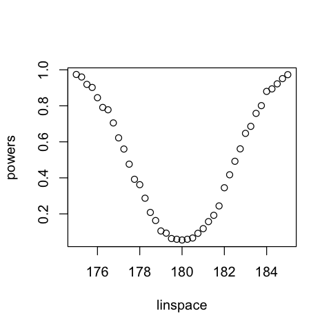

```r
powers = sapply(linspace, pwr)
plot(x=linspace, y=powers)
```

b.) Set n=m=100, mu=180 and sd=5. Repeat the preceding exercise. Add the plot to the preceding plot

### Changing the sample size

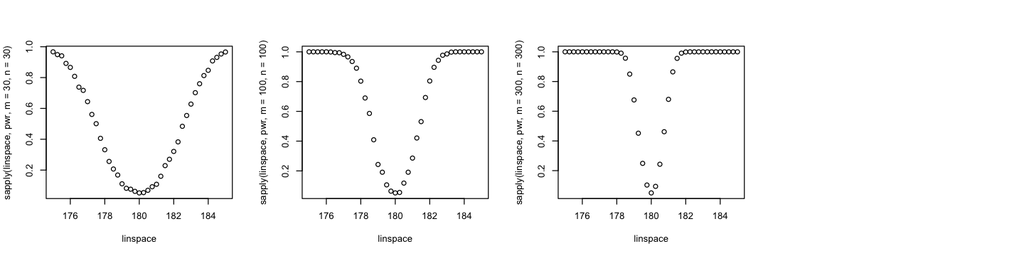

```r
par(mfrow=c(1,4));options(repr.plot.width=12, repr.plot.height=3)
plot(x=linspace, y=sapply(linspace, pwr, m=30, n=30));
plot(x=linspace, y=sapply(linspace, pwr, m=100, n=100));
plot(x=linspace, y=sapply(linspace, pwr, m=300, n=300));
```

c.) Set n=m=30, mu=180 and sd=15. Repeat the preceding exercise.

### Changing the std

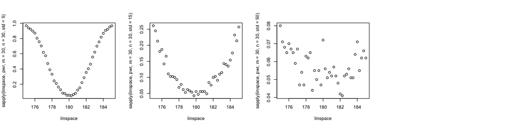

```r
par(mfrow=c(1,4));options(repr.plot.width=12, repr.plot.height=3)
plot(x=linspace, y=sapply(linspace, pwr, m=30, n=30, std=5));
plot(x=linspace, y=sapply(linspace, pwr, m=30, n=30, std=15));
plot(x=linspace, y=sapply(linspace, pwr, m=30, n=30, std=50));
```

Both the sample size and the std of the samples have an impact on the power of the tests. \ Large sample sizes will make the test near to optimal, indicated by approaching a step function for $p\in \{0,1\}$. \ Increasing the standard deviation makes any kind of sensible test and its power less stable and ultimately noisy.

## Exc 3. - telecommunication company

A telecommunication company has entered the market for mobile phones in a new country. The company’s marketing manager conducts a survey of 200 new subscribers for mobile phones. The results of the survey are in the data set telephone.txt, which contains the first month bills X1, . . . X200, in euros

a.) Make an appropriate plot of this data set. What marketing advice(s) would you give to the marketing manager? Are there any inconsistencies in the data? If so, try to fix these.

```r
survey=read.table("telephone.txt",header=TRUE)$Bills
summary(survey)
```

```
   Min. 1st Qu.  Median    Mean 3rd Qu.    Max.
  0.000   9.385  26.905  43.588  84.828 119.630
```

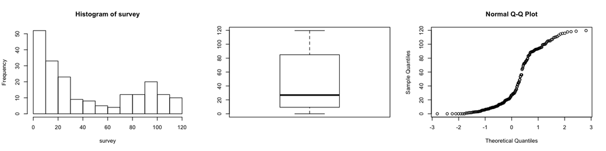

```r
par(mfrow=c(1,3));options(repr.plot.width=12, repr.plot.height=3)
hist(survey)
boxplot(survey)
qqnorm(survey)
```

The summary stats as well as the boxplot reveal that we have 0.00 bills in the data. At this point we cant be sure if those zero data points are due to errors e.g input errors, but they could also be originated in first month discounts. Either way we cannot use those data points since they dont represent from the true population of bills.

Now the above plots reveal that the data cannot be assumed to normal, given both the histogram and the QQ-Plot. The Boxplot reveals high variance within the data. The histogram also indicates a potential bimodal origin density for the observed data.

```r
survey = survey[survey!=0]
```

We effectivley omit 8 data points by omitting zero bills. and continue with $n=192$ datapoints.

```r
summary(survey)
```

```
   Min. 1st Qu.  Median    Mean 3rd Qu.    Max.
   0.98   10.84   28.91   45.40   87.91  119.63
```

## Bootstrap test

b) By using a bootstrap test with the test statistic T = median(X1, . . . , X200), test whether the data telephone.txt stems from the exponential distribution Exp(λ) with some λ from [0.01, 0.1].

$$ H_0 \gets X \sim \text{exp}(\lambda) $$

with $T(X)$ as the median, i.e $T^{*}_b = T(X^{*}_b)$.

```r
# Median of original data
t_init = median(survey)
t_init
```

28.905

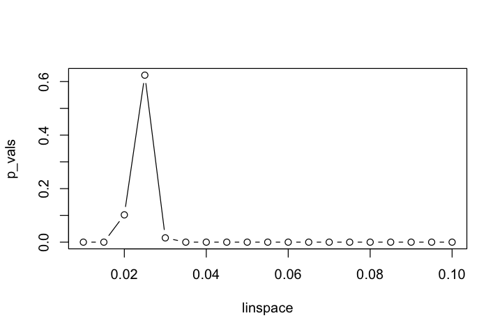

```r
linspace= seq(0.01, 0.1,by=0.005)
p_vals = c()
for(lambda in linspace){
    B = 1000
    T_star = numeric(B)
    for(b in 1:B){
        # Create bootstrap sample of same size as original sample drawn from exp(lambda)
        X_star=rexp(length(survey), lambda)
        # Compute test statistic for b-th bootstrap sample
        T_star[b]=median(X_star)
    }
    pl = sum(T_star<t_init)/B;
    pr = sum(T_star>t_init)/B;
    p = 2*min(pl, pr);
    p_vals = c(p_vals,p)
}
options(repr.plot.width=6, repr.plot.height=4)
plot(x=linspace, y=p_vals,type="b")
```

## Bootstrap CI

c) Construct a 95% bootstrap confidence interval for the population median of the sample

```r
B=1000
Tstar=numeric(B)
for(i in 1:B) {
    Xstar=sample(survey,replace=TRUE)
    Tstar[i]=median(Xstar)
}
Tstar25=quantile(Tstar,0.025)
Tstar975=quantile(Tstar,0.975)
c(2*t_init-Tstar975, 2*t_init-Tstar25)
```

**97.5%**

17.093

**2.5%**

36.575

d) Assuming X1, . . . Xn ∼ Exp(λ) and using the central limit theorem for the sample mean, estimate λ and construct again a 95% confidence interval for the population median. Comment on your findings.

```r
# Mean of original data
t_init = mean(survey)
t_init
```

45.40375

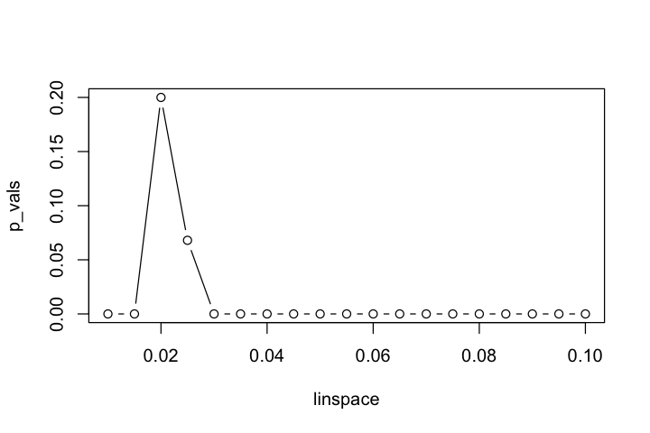

```r
p_vals = c()
for(lambda in linspace){
    B = 1000
    T_star = numeric(B)
    for(b in 1:B){
        # Create bootstrap sample of same size as original sample drawn from exp(lambda)
        X_star=rexp(length(survey), lambda)
        # Compute test statistic for b-th bootstrap sample
        T_star[b]=mean(X_star)
    }
    pl = sum(T_star<t_init)/B;
    pr = sum(T_star>t_init)/B;
    p = 2*min(pl, pr);
    p_vals = c(p_vals,p)
}
plot(x=linspace, y=p_vals,type="b")
```

```r
t_init = mean(survey)
B=1000
Tstar=numeric(B)
for(i in 1:B) {
    Xstar=sample(survey,replace=TRUE)
    Tstar[i]=median(Xstar)
}
Tstar25=quantile(Tstar,0.025)
Tstar975=quantile(Tstar,0.975)
c(2*t_init-Tstar975, 2*t_init-Tstar25)
```

**97.5%**

50.5125

**2.5%**

69.5725

### Using CLT to evaluate $\lambda \in \{0.025, 0.02\}$.

For the exponential distribution with $\mu=\frac{1}{\lambda}$ and $\sigma^2 =\frac{1}{\lambda^2}$ we can use the CLT to standardize $\bar{X}$ into $\frac{\bar{X}-\mu}{\sigma / \sqrt{n}}=\frac{\bar{X}-1 / \lambda}{\frac{1}{\lambda} / \sqrt{n}}$, which we can simplify to $\sqrt{n}(\lambda \bar{X}-1)$, for which it is non-trivial to show that $\sqrt{n}(\lambda \bar{X}-1) \sim N(0,1)$ . For every lambda we can generate a bunch of samples with the same size as the initial sample and get the distribution of $\sqrt{n}(\lambda \bar{X}-1)$. We can then compare our initial value with the two distributions to obtain two p-values.

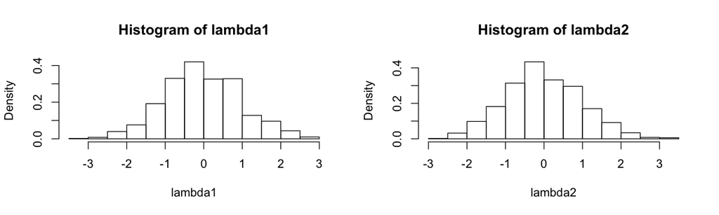

```r
B = 1000
t_init_1 = sqrt(length(survey))*(0.025*mean(survey) - 1)
t_init_2 = sqrt(length(survey))*(0.020*mean(survey) - 1)
lambda1 = numeric(B)
lambda2 = numeric(B)
p_vals_1 = c()
p_vals_2 = c()
for(b in 1:B){
    X_star1=rexp(length(survey), 0.025)
    X_star2=rexp(length(survey), 0.020)
    # Compute normalized mean
    lambda1[b]=sqrt(length(survey))*(0.025*mean(X_star1) - 1)
    lambda2[b]=sqrt(length(survey))*(0.020*mean(X_star2) - 1)
}
    pl = sum(lambda1<t_init_1)/B;
    pr = sum(lambda1>t_init_1)/B;
    p = 2*min(pl, pr);
    p_vals_1 = c(p_vals_1,p)
    pl = sum(lambda2<t_init_2)/B;
    pr = sum(lambda2>t_init_2)/B;
    p = 2*min(pl, pr);
    p_vals_2 = c(p_vals_2,p)
par(mfrow=c(1,2));options(repr.plot.width=10, repr.plot.height=3)
hist(lambda1,prob=TRUE);hist(lambda2,prob=TRUE)
```

```r
c(p_vals_2,#.020
  p_vals_1)#.025
```

1. 0.19

2. 0.062

Given $p_{\lambda=0.02} > p_{\lambda=0.025}$, we essentially end up at the same conclusion as using a bootstrap test with mean as test statistic.

e.1)Using an appropriate test, test the null hypothesis that the median bill is bigger or equal to 40 euro against the alternative that the median bill is smaller than 40 euro.

```r
median(survey)
```

28.905

$H_0 : m \geq 40$

By definition of the median, 50% of the values lie above/below. If $m \geq 40$ then we expect that **at least** $\frac{n}{2}$ of the values are smaller than 40.

$$ m=40 \implies P(X < 40) = P(X > 40) \\ m>40 \implies P(X < 40) > P(X > 40) \\ m<40 \implies P(X < 40) < P(X > 40) \\ $$

For $m \geq 40$, $P(X < 40) \geq 0.5$ must hold.

```r
length(survey[survey < 40])/length(survey)
```

0.567708333333333

```r
binom.test(length(survey[survey < 40]), length(survey), p = 0.5, alternative="less")
```

```
	Exact binomial test

data:  length(survey[survey < 40]) and length(survey)
number of successes = 109, number of trials = 192, p-value = 0.9745
alternative hypothesis: true probability of success is less than 0.5
95 percent confidence interval:
 0.0000000 0.6280198
sample estimates:
probability of success
             0.5677083
```

We cannot reject $H_0$. The true probability is likeli to be above 50%, which is what we were asking for!

e.2) Next, design and perform a test to check whether the fraction of the bills less than 10 euro is less than 25%.

```r
length(survey[survey < 10]) / length(survey)
```

0.229166666666667

```r
binom.test(length(survey[survey < 10]), length(survey), p = 0.25, alternative="greater")
```

```
	Exact binomial test

data:  length(survey[survey < 10]) and length(survey)
number of successes = 44, number of trials = 192, p-value = 0.7715
alternative hypothesis: true probability of success is greater than 0.25
95 percent confidence interval:
 0.180075 1.000000
sample estimates:
probability of success
             0.2291667
```

Again, we cannot reject the hypothesis.

## Exc.4 - Energy Drink

To study the effect of energy drink a sample of 24 high school pupils were randomized to drinking either a softdrink or an energy drink after running for 60 meters. After half an hour they were asked to run again. For both sprints they were asked to sprint as fast they could, and the sprinting time was measured. The data is given in the file run.txt.

```r
df=data.frame(read.table("run.txt",header=TRUE))
```

```r
head(df)
```

A data.frame: 6 × 3

|  | before <dbl> | after <dbl> | drink <fct> |
| --- | --- | --- | --- |
| 1 | 7.92 | 6.99 | lemo |
| 2 | 7.56 | 8.14 | lemo |
| 3 | 7.62 | 8.09 | lemo |
| 4 | 6.85 | 6.40 | lemo |
| 5 | 7.87 | 8.79 | lemo |
| 6 | 7.41 | 6.60 | lemo |

a.) Disregarding the type of drink, test whether the run times before drink and after are correlated.

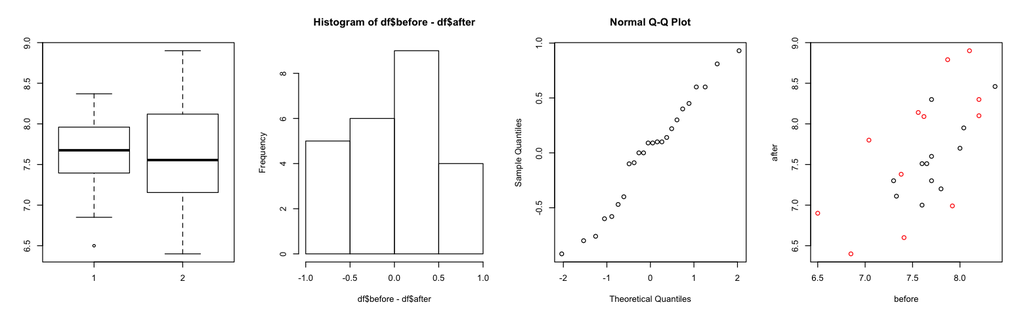

```r
options(repr.plot.width=13, repr.plot.height=4);
par(mfrow=c(1,4))
boxplot(df$before,df$after)
hist(df$before-df$after)
qqnorm(df$before-df$after)
plot(after ~ before, col = drink, data = df)
```

```r
cor.test(df$before, df$after)
```

```
	Pearson's product-moment correlation

data:  df$before and df$after
t = 3.8944, df = 22, p-value = 0.00078
alternative hypothesis: true correlation is not equal to 0
95 percent confidence interval:
 0.3171271 0.8286612
sample estimates:
     cor
0.638803
```

If we assume normality, which is hard for $n=24$,indicated by the QQPlot of the differences, there is a significant correlation.

```r
cor.test(df$before, df$after,method="spearman")
```

```
	Spearman's rank correlation rho

data:  df$before and df$after
S = 859.18, p-value = 0.001056
alternative hypothesis: true rho is not equal to 0
sample estimates:
      rho
0.6264432
```

b.) Test separately, for both the softdrink and the energy drink conditions, whether there is a difference in speed in the two running tasks.

For each condition, we test $H_0 : \mu_0 - \mu_1 = 0$.

```r
# LEMON condition
before = df[df$drink == "lemo",]$before
after = df[df$drink == "lemo",]$after
t.test(before, after,paired=TRUE)
```

```
	Paired t-test

data:  before and after
t = -0.80596, df = 11, p-value = 0.4373
alternative hypothesis: true difference in means is not equal to 0
95 percent confidence interval:
 -0.5409781  0.2509781
sample estimates:
mean of the differences
                 -0.145
```

```r
# ENERGY condition
before = df[df$drink != "lemo",]$before
after = df[df$drink != "lemo",]$after
t.test(before, after,paired=TRUE)
```

```
	Paired t-test

data:  before and after
t = 1.6538, df = 11, p-value = 0.1264
alternative hypothesis: true difference in means is not equal to 0
95 percent confidence interval:
 -0.05101059  0.35934392
sample estimates:
mean of the differences
              0.1541667
```

Tested seperately, the paired t-test indicates that we cannot reject $H_0$ under both conditions. Both drinks dont have a signigidcant effect on running time.

c.) For each pupil compute the time difference between the two running tasks. Test whether these time differences are effected by the type of drink.

```r
lemon_diff = df[df$drink == "lemo",]$before - df[df$drink == "lemo",]$after
energy_diff = df[df$drink != "lemo",]$before - df[df$drink != "lemo",]$after
```

```r
t.test(lemon_diff, energy_diff)
```

```
	Welch Two Sample t-test

data:  lemon_diff and energy_diff
t = -1.4764, df = 16.509, p-value = 0.1586
alternative hypothesis: true difference in means is not equal to 0
95 percent confidence interval:
 -0.7276409  0.1293076
sample estimates:
 mean of x  mean of y
-0.1450000  0.1541667
```

We cannot reject $H_0$. CHeck if t test is possible:

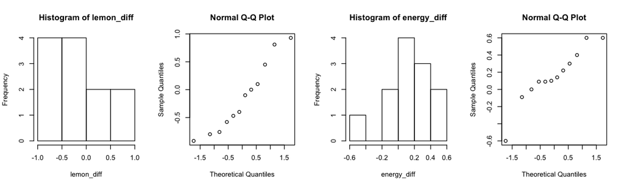

```r
options(repr.plot.width=10, repr.plot.height=3);
par(mfrow=c(1,4))
hist(lemon_diff)
qqnorm(lemon_diff)
hist(energy_diff)
qqnorm(energy_diff)
```

Because the t-test is not suitable here, we use the wilcox test

```r
wilcox.test(lemon_diff, energy_diff)
```

```
	Wilcoxon rank sum test with continuity correction

data:  lemon_diff and energy_diff
W = 45.5, p-value = 0.1332
alternative hypothesis: true location shift is not equal to 0
```

Again, we cannot reject $H_0$.

d.) Can you think of a plausible objection to the design of the experiment in b) if the main aim was to test whether drinking the energy drink speeds up the running? Is there a similar objection to the design of the experiment in c)? Comment on all your findings in this exercise.

Most was already explained above. \ Regarding the testing design, we can use the paired t-test when we want to test before/after effects, since before/after are conditions applied to the same subjects. However, comparing lemon/energy in this particular case should be tested using the two sample t test because regardless of before/after, lemon/energy are distinct (independant) densities.

### Exc. 5 - Chickweights

```r
head(chickwts, 3)
```

A data.frame: 3 × 2

|  | weight <dbl> | feed <fct> |
| --- | --- | --- |
| 1 | 179 | horsebean |
| 2 | 160 | horsebean |
| 3 | 136 | horsebean |

a.) Test whether the distributions of the chicken weights for meatmeal and sunflower groups are different by performing three tests: the two samples t-test (argue whether the data are paired or not), the Mann-Whitney test and the Kolmogorov-Smirnov test. Comment on your findings.

```r
meatmeal = chickwts[chickwts$feed == "meatmeal",]$weight
sunflower = chickwts[chickwts$feed == "sunflower",]$weight
```

##### a.1) Two sample t-test

The data does not come in the form of matched pairs, but the experiments are rather statistically independent. Thats why we cannot perform the paired t test. If we would have two outcomes per unit (chicken) we could do the paired test. Using the two sample t-test, we find that $H_0 : \mu_1 = \mu_2$ needs to be rejected for $\alpha=0.05$.

```r
t.test(meatmeal, sunflower)
```

```
	Welch Two Sample t-test

data:  meatmeal and sunflower
t = -2.1564, df = 18.535, p-value = 0.04441
alternative hypothesis: true difference in means is not equal to 0
95 percent confidence interval:
 -102.572435   -1.442716
sample estimates:
mean of x mean of y
 276.9091  328.9167
```

##### a.2) Mann-Whitney Test

Now using a rank-based method, namely the Mann-Whitney test, we are able to evaluate $H_0 : f_1 = f_2$, specifically the location shift of the underlying densities $f_1, f_2$ is assumed to be zero in $H_0$. For $\alpha=0.05$, we cannot reject $H_0$ according to the Mann-Whitney test, which is contrary to the first test, although the two sample t-test is only slight off with $p=0.044$.

```r
wilcox.test(meatmeal, sunflower)
```

```
	Wilcoxon rank sum test

data:  meatmeal and sunflower
W = 36, p-value = 0.06882
alternative hypothesis: true location shift is not equal to 0
```

##### a.3) Kolmogorov Smirnov Test

Using the eCDFs of the samples, we can use the KS-test to again evaluate $H_0 : f_1 = f_2$ . The two-sample K–S test is much more useful than the methods used before, not only because it is mostly assumptionless, but because it is sensitive to differences in both location **and** shape of the underlying distributions (unlike the previous tests). The KS-test accepts $H_0$ with $\alpha=0.05$

```r
ks.test(meatmeal, sunflower)
```

```
	Two-sample Kolmogorov-Smirnov test

data:  meatmeal and sunflower
D = 0.47727, p-value = 0.1085
alternative hypothesis: two-sided
```

b.) Conduct a one-way ANOVA to determine whether the type of feed supplement has an effect on the weight of the chicks. Give the estimated chick weights for each of the six feed supplements. What is the best feed supplement?

```r
model = lm(weight~feed,data=chickwts)
print(round(anova(model),3))
```

```
Analysis of Variance Table

Response: weight
          Df Sum Sq Mean Sq F value    Pr(>F)
feed       5 231129   46226  15.365 < 2.2e-16 ***
Residuals 65 195556    3009
---
Signif. codes:  0 ‘***’ 0.001 ‘**’ 0.01 ‘*’ 0.05 ‘.’ 0.1 ‘ ’ 1
```

For the factor test we evaluate $H_0 : \mu_1 = \mu_2 = ... \mu_l$ , given the $l$ factors (feed types), i.e there is no difference in weihgt among feed types. Like in the previous tests, the larger the test statistic (in this case the F-value) the more likely $H_0$ is rejected. The observed p-value of $H_0$ is very small and we therefore need to reject $H_0$, indicating significant difference in weight among the factors.

```r
summary(model)
```

```
Call:
lm(formula = weight ~ feed, data = chickwts)

Residuals:
     Min       1Q   Median       3Q      Max
-123.909  -34.413    1.571   38.170  103.091

Coefficients:
              Estimate Std. Error t value Pr(>|t|)
(Intercept)    323.583     15.834  20.436  < 2e-16 ***
feedhorsebean -163.383     23.485  -6.957 2.07e-09 ***
feedlinseed   -104.833     22.393  -4.682 1.49e-05 ***
feedmeatmeal   -46.674     22.896  -2.039 0.045567 *
feedsoybean    -77.155     21.578  -3.576 0.000665 ***
feedsunflower    5.333     22.393   0.238 0.812495
---
Signif. codes:  0 ‘***’ 0.001 ‘**’ 0.01 ‘*’ 0.05 ‘.’ 0.1 ‘ ’ 1

Residual standard error: 54.85 on 65 degrees of freedom
Multiple R-squared:  0.5417,	Adjusted R-squared:  0.5064
F-statistic: 15.36 on 5 and 65 DF,  p-value: 5.936e-10
```

From the summary table of the linear model we can see that casein serves as the baseline factor.

$$ (\mu_0, \mu_1, \mu_2, \mu_3, \mu_4, \mu_5) \gets (323.6, 160.2, 218.8, 276.9, 246.4, 328.9) $$

c.) Check the ANOVA model assumptions by using relevant diagnostic tools

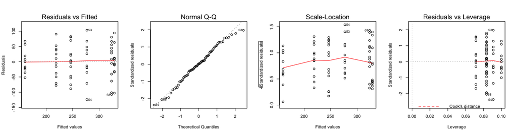

```r
options(repr.plot.width=13, repr.plot.height=3.4);par(mfrow=c(1,4
                                                            ));
plot(model)
```

We dont have to be too afraid regarding the normality assumption (see above).

d.) Does the Kruskal-Wallis test arrive at the same conclusion about the effect of feed supplement as the test in b)? Explain possible differences between conclusions of the Kruskal-Wallis and ANOVA tests

```r
kruskal.test(chickwts$weight,chickwts$feed)
```

```
	Kruskal-Wallis rank sum test

data:  chickwts$weight and chickwts$feed
Kruskal-Wallis chi-squared = 37.343, df = 5, p-value = 5.113e-07
```

While ANOVA/t-tests basically compares means, Kruskal-Wallis/Mann-Whitney is comparing the mean ranks, which is more general and works not only for samples that stem from normal densities. For large factor effects like the ones shown in this dataset, both tests will very likeli come to the same conclusion, although they are, as previously described, not necessarily measuring the same underyling population metrics.